```python
from PIL import Image
from scipy import ndimage
from scipy import signal
from timeit import default_timer as timer
import numpy as np
import matplotlib.pyplot as plt
import math as math
import glob
import os
import sys

sys.path.append("../lab1/") # set the path for visualPercepUtils.py
import visualPercepUtils as vpu

figure_size=(7, 7)
plt.gray()
plt.rcParams['figure.figsize'] = [10,5]
```

```python
def addSPNoise(im, percent):
    # Now, im is a PIL image (not a NumPy array)
    # percent is in range 0-100 (%)

    # convert image it to numpy 2D array and flatten it
    im_shape = im.shape  # keep shape for later use (*)
    im_vec = im.flatten()  # this is a 1D array # https://www.geeksforgeeks.org/differences-flatten-ravel-numpy/

    # generate random locations
    N = im_vec.shape[0]  # number of pixels
    m = int(math.floor(percent * N / 100.0)) # number of pixels corresponding to the given percentage
    locs = np.random.randint(0, N, m)  # generate m random positions in the 1D array (index 0 to N-1)

    # generate m random S/P values (salt and pepper in the same proportion)
    s_or_p = np.random.randint(0, 2, m)  # 2 random values (0=salt and 1=pepper)

    # set the S/P values in the random locations
    im_vec[locs] = 255 * s_or_p  # values after the multiplication will be either 0 or 255

    # turn the 1D array into the original 2D image
    im2 = im_vec.reshape(im_shape) # (*) here is where we use the shape that we saved earlier

    # convert Numpy array im2 back to a PIL Image and return it
    return im2
```

```python
def addGaussianNoise(im, sd=5):
    return im + np.random.normal(loc=0, scale=sd, size=im.shape)
```

# Exercise 2

```python
def averageFilter(im, filterSize):
    mask = np.ones((filterSize, filterSize))
    mask = np.divide(mask, mask.shape[0]*mask.shape[1]) # can you think of any alternative for np.sum(mask)?
    # return ndimage.convolve(im, mask, 'float64')
    return ndimage.convolve(im, mask)
```

It is really interesting to see the differences in execution times. It seems that while the separate filter is constant with the filter size, the full filter is dependant of the filter size.

```python
def averageFilterSep(im, filterSize):
    maskh = np.ones((1,filterSize))
    maskv = np.ones((filterSize, 1))
    maskh = np.divide(maskh, maskh.shape[1])
    maskv = np.divide(maskv, maskv.shape[0])
    im2 = ndimage.convolve(im, maskv, 'float64') # For avoiding truncation errors.
    im3 = ndimage.convolve(im2, maskh, 'uint8') # Black & white images are arrays of uint8 data type in pillow.
    return im3
```

```
2 None None
```

[figure not shown]

```python
im = np.array(Image.open('./imgs-P2/lena256.pgm').convert('L'))
im_dirty = addSPNoise(im, 3) # salt and pepper noise
vpu.showInGrid([im, im_dirty], figure_size, subtitles=["Original", "With 3% salt and pepper"])
```

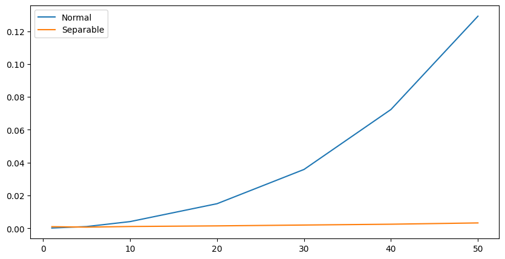

```python
filterSizes = [1, 5, 10, 20, 30, 40, 50]
time_normal = []
time_sep = []
for f in filterSizes:
    start = timer()
    im2 = averageFilterSep(im_dirty, f)
    end = timer()
    time_sep.append(end - start)
    start = timer()
    im3 = averageFilter(im_dirty, f)
    end = timer()
    time_normal.append(end - start)

plt.plot(filterSizes, time_normal)
plt.plot(filterSizes, time_sep)
plt.legend(('Normal', 'Separable'))
```

As you can see there is no appreciable difference in the image. But if you look at the difference between the two transformed images, with the sepparate and not separate filter there are suttle differences in some pixels that I think are related to the specifics of how the images are processed and transformed by numpy and scipy. Maybe some things related to some variations in data type transformations. Some operations are done using `float64` type in numpy, but as images are defined as arrays with `uint8` data there might be some differences as how some truncation or rounding errors might be treated. I had a lot of trouble with this exercise because at the begining I compared the resulting arrays instead of comparing the image plots. I spent hours trying to identify the problem because I though that if the arrays were not the same I made some mistake, until I realized the problem might be because of the data types and that the differences in the array were not appreciable when plotting the image.

```
2 None None
```

[figure not shown]

```python
im2 = averageFilterSep(im_dirty, 10)
im3 = averageFilter(im_dirty, 10)
vpu.showInGrid([im3, im2], figure_size, subtitles=["Full Average", "Separate Average"])
```

```python
im4 = im3-im2
```

```python
im3[(im4!=0)]
```

```
array([132, 154, 123, 109, 125, 130, 133, 134, 154, 134, 130, 121, 164,
       165, 130, 164, 119, 133, 166, 158, 121, 109, 155, 152, 139, 118,
       158, 115, 149, 148, 147,  56, 143, 112, 149, 174, 176, 152, 135,
       152, 160, 118, 139, 120, 122, 122, 139, 183,  85, 119,  97, 125,
        88, 207,  62, 133, 130, 182,  54,  54,  98, 132, 174, 191, 158,
       156, 110, 108, 191, 116, 120, 102, 198, 101, 125, 191,  54, 113,
       170, 169, 164, 176, 197, 179, 175, 140, 167, 145, 167, 143, 167,
       143, 189,  99, 138, 108,  97, 129, 108, 126, 165, 156,  97, 153,
       154,  75,  65,  53, 119, 162, 168, 182, 107,  58, 135, 109, 109,
       118,  60,  94, 135, 170, 110,  68,  68, 101, 162,  63, 105, 154,
        60, 169, 192,  94, 126, 114, 104, 131, 101, 102, 151,  62, 105,
       114,  77, 174,  89, 133,  53,  83, 153, 131,  69,  77,  72, 111,
        74,  95, 139, 153,  84, 206, 141,  61, 161, 163, 105, 100,  68,
        67, 134, 144, 204, 106, 139,  54,  87, 102,  84, 198, 202, 109,
       141, 164, 123, 147,  86, 105,  55,  64,  84,  57,  57,  83,  78,
        92, 117,  83, 109, 137, 183, 171, 176,  97, 147,  92, 132,  58,
        59, 178, 147,  64, 149, 206, 124,  74, 114, 106, 146, 148, 166,
       152,  57,  63, 140, 103,  91, 174, 193,  59, 110, 109, 133, 144,
        86,  83,  72, 165, 168, 163, 190,  84, 142, 183, 148,  64,  85,
       152, 179,  97, 178], dtype=uint8)
```

```python
im2[im4!=0]
```

```
array([133, 155, 124, 110, 126, 131, 134, 135, 153, 135, 131, 122, 165,
       166, 131, 165, 120, 134, 167, 159, 122, 110, 156, 153, 140, 119,
       159, 116, 150, 149, 148,  57, 144, 113, 150, 175, 177, 153, 136,
       153, 161, 119, 140, 121, 123, 123, 140, 184,  86, 120,  98, 126,
        89, 208,  63, 134, 131, 183,  55,  55,  99, 133, 175, 192, 159,
       157, 111, 109, 192, 117, 121, 103, 199, 102, 126, 192,  55, 114,
       171, 170, 165, 177, 198, 180, 176, 141, 168, 146, 168, 144, 168,
       144, 190, 100, 139, 109,  98, 130, 109, 127, 166, 157,  98, 154,
       155,  76,  66,  54, 120, 163, 169, 183, 108,  59, 136, 110, 110,
       119,  61,  95, 136, 171, 111,  69,  69, 102, 163,  64, 106, 155,
        61, 170, 193,  95, 127, 115, 105, 132, 102, 103, 152,  63, 106,
       115,  78, 175,  90, 134,  54,  82, 154, 132,  70,  78,  73, 112,
        75,  96, 140, 154,  85, 207, 142,  62, 162, 164, 106, 101,  69,
        68, 135, 145, 205, 107, 140,  55,  88, 103,  85, 199, 203, 110,
       142, 165, 124, 148,  87, 106,  56,  65,  85,  58,  58,  84,  79,
        93, 118,  84, 110, 138, 184, 172, 177,  98, 148,  93, 133,  59,
        60, 179, 148,  65, 150, 207, 125,  75, 115, 107, 147, 149, 167,
       153,  58,  64, 141, 104,  92, 175, 194,  60, 111, 110, 134, 145,
        87,  84,  73, 166, 169, 164, 191,  83, 143, 184, 149,  65,  86,
       153, 180,  98, 179], dtype=uint8)
```

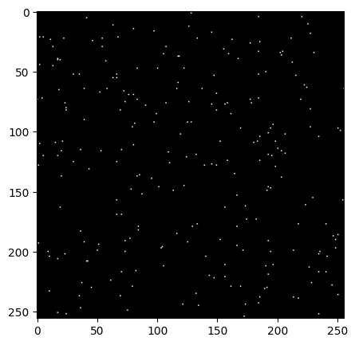

```python
plt.imshow(im4)
```